```python
from sklearn.metrics import confusion_matrix
from sklearn.svm import LinearSVC
from sklearn.tree import DecisionTreeClassifier
from sklearn.model_selection import train_test_split
from sklearn.datasets import load_iris
from sklearn.metrics import accuracy_score
from sklearn.metrics import confusion_matrix
```

# Classification

### Support Vector Machine (SVM)

Let us copy the snippet from previous tutorial for reference:

### ML Algorithms General Form:

We can write about every machine learning algorithm that exists in the following canonical form: the goal of any machine learning algorithm is to find the parameters that minimize the average of losses on the data. This problem is written formally as:

$$ minimize_{\theta} \ \frac{1}{m} \sum_{1}^{m} l(h_{\theta}(x^{(i)}, y^i) = minimize_{\theta} \ E(\theta)$$

In the next tutorial, we'll study classification algorithms logistic regression, support vector machine etc and you'll to define them (or any ML algorithm in general) we'll specify Hypothesis function, Loss function and the way to optimize loss function just like we did here.

### Loss functions in Classification

For classification, loss functions are the one element that is substantially different from the ones in regression.

We can naively use least-squares loss function for classification as we did in regression however when applied to classification it aims at predicting exactly +1 or −1 on each data point which is wrong in the sense that for a positive class we're also okay with a number much greater than +1. Similarly, for a negative class we're also okay with a number much less than -1. You've already seen logistic loss, another commonly used loss in ML is hinge loss.

## Hinge Loss for SVM

Support vector machines (SVMs) result from choosing hinge loss

$$l_{hinge}(h_{\theta}(x),y)= max(1 − h_{\theta}(x)⋅y, 0))$$

as the loss function to minimize.

Weston and Watkins extension of hinge loss for multiclass classification is also common:

$$l_{hinge}(h_{\theta}(x),y)= \sum_{y \neq t} max(0, \Delta + w_y x - w_t x))$$

The (extension) SVM loss is set up so that the SVM “wants” the correct class for each image to a have a score higher than the incorrect classes by some fixed margin Δ.

More on [Hinge Loss](https://en.wikipedia.org/wiki/Hinge_loss).

### Hypothesis Functions (Linear vs Non-Linear SVMs)

Hypothesis function could either be linear (as in linear regression, and logistic regression) or it could be kernel (non-linear).

The terminologies “linear SVM” or “kernel SVM”, are just the designations of which type of hypothesis function they are using. That is, linear SVMs use the hypothesis function:

$$ h_{\theta}(x) = \sum_{j=1}^{n} \theta_j x_j = \theta^T x $$

exactly as we have seen before in the linear regression case. While a kernel SVM uses the hypothesis function:

$$ h_{\theta}(x) = \sum_{i=1}^{n} \theta_i K (x, x^{(i)}) $$

Where K is a kernel function. More on this [here](http://cs229.stanford.edu/notes/cs229-notes3.pdf).

### Plot

##### Exercise

```python
import numpy as np
import matplotlib.pyplot as plt
```

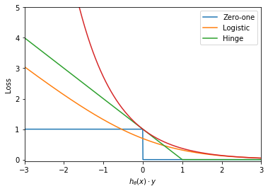

```python
hy = np.linspace(-3,3,1000)
plt.plot(hy,(hy<=0))
plt.plot(hy, np.log(1+np.exp(-hy)))
plt.plot(hy, np.maximum(1 - hy, 0))
plt.plot(hy, np.exp(-hy))
plt.xlim([-3,3])
plt.ylim([-0.05, 5])
plt.ylabel("Loss")
plt.xlabel("$h_θ(x) \cdot y$")
plt.legend(['Zero-one', 'Logistic', 'Hinge'])
```

This is an excellent [demo](http://vision.stanford.edu/teaching/cs231n-demos/linear-classify/) for playing with SVM (which uses the hinge loss- proposed by Weston and Watkins)

## Implemetation of linear svm using sklearn

### Iris Dataset

Let's load [iris dataset](https://scikit-learn.org/stable/modules/generated/sklearn.datasets.load_iris.html#sklearn-datasets-load-iris) form sklearn. There are 3 classes (labels) in this dataset. See this [guide](https://scikit-learn.org/stable/datasets/index.html#iris-plants-dataset) for more information on dataset.

This is the same dataset we used in the prvious tutorial.

```python
iris = load_iris()
```

```python
features = iris.data
labels = iris.target
labels_names = iris.feature_names
```

```python
labels_names
```

```
['sepal length (cm)',
 'sepal width (cm)',
 'petal length (cm)',
 'petal width (cm)']
```

### Train/Test Split

Use sklearn as in previous tutorial.

```python
x_train, x_test, y_train, y_test = train_test_split(features, labels,\
                                                    test_size=.3, random_state=32)
```

```python
svm_lin_clf = LinearSVC(max_iter=50000)
svm_lin_clf.fit(x_train, y_train)
```

```
LinearSVC(C=1.0, class_weight=None, dual=True, fit_intercept=True,
          intercept_scaling=1, loss='squared_hinge', max_iter=50000,
          multi_class='ovr', penalty='l2', random_state=None, tol=0.0001,
          verbose=0)
```

### Exercise

Find the least number of iterations to ensure convergence. Currently, it's set 50000 which is more than the minimum number required.

```python
y_pred = svm_lin_clf.predict(x_test) # predict on test data
y_pred
```

```
array([1, 0, 0, 1, 2, 2, 0, 0, 1, 0, 1, 2, 1, 1, 2, 2, 1, 2, 1, 0, 0, 2,
       2, 0, 0, 1, 0, 2, 0, 0, 1, 0, 0, 2, 1, 0, 0, 2, 2, 1, 0, 2, 0, 2,
       0])
```

```python
svm_lin_clf.score(x_test, y_test) # R2 score.
```

```
1.0
```

```python
accuracy_score(y_test, y_pred) # accuracy
```

```
1.0
```